# DEM 5093/7093 Lab 1 using R - Basic Map making

Corey Sparks, Ph.D.

27 January, 2022

### Get a Census developer API Key

Obtain one at the Census Developer [website](http://api.census.gov/data/key_signup.html)

### Save your API key to your working directory

use

```
tidycensus::census_api_key(key =  "yourkeyhere", install =
T)
```

One time to install your key for use in `tidycensus`

```r
library(tidycensus)
library(tidyverse)
library(sf)
library(ggplot2)
library(classInt)
```

### Examine data profile tables

The `load_variables()` function will load all available variables in the ACS for a given year

```r
v15_Profile <- load_variables(year = 2019 ,
                              dataset =  "acs5/profile",
                              cache = TRUE)
```

Calling `View(v15_Profile)` will let you interactively browse and filter the ACS variables, this is one way to search for what you’re looking for.

### Search for variables by keywords in the label

```r
v15_Profile%>%
  filter(grepl(pattern = "POVERTY", x = label))%>%
  select(name, label)
```

```
## # A tibble: 38 x 2
##    name       label
##    <chr>      <chr>
##  1 DP03_0119  Estimate!!PERCENTAGE OF FAMILIES AND PEOPLE WHOSE INCOME IN THE P~
##  2 DP03_0119P Percent!!PERCENTAGE OF FAMILIES AND PEOPLE WHOSE INCOME IN THE PA~
##  3 DP03_0120  Estimate!!PERCENTAGE OF FAMILIES AND PEOPLE WHOSE INCOME IN THE P~
##  4 DP03_0120P Percent!!PERCENTAGE OF FAMILIES AND PEOPLE WHOSE INCOME IN THE PA~
##  5 DP03_0121  Estimate!!PERCENTAGE OF FAMILIES AND PEOPLE WHOSE INCOME IN THE P~
##  6 DP03_0121P Percent!!PERCENTAGE OF FAMILIES AND PEOPLE WHOSE INCOME IN THE PA~
##  7 DP03_0122  Estimate!!PERCENTAGE OF FAMILIES AND PEOPLE WHOSE INCOME IN THE P~
##  8 DP03_0122P Percent!!PERCENTAGE OF FAMILIES AND PEOPLE WHOSE INCOME IN THE PA~
##  9 DP03_0123  Estimate!!PERCENTAGE OF FAMILIES AND PEOPLE WHOSE INCOME IN THE P~
## 10 DP03_0123P Percent!!PERCENTAGE OF FAMILIES AND PEOPLE WHOSE INCOME IN THE PA~
## # ... with 28 more rows
```

```r
v15_Profile%>%
  filter(grepl(pattern = "Built 2000 to 2009", x = label))%>%
  select(name, label)
```

```
## # A tibble: 2 x 2
##   name       label
##   <chr>      <chr>
## 1 DP04_0019  Estimate!!YEAR STRUCTURE BUILT!!Total housing units!!Built 2000 to~
## 2 DP04_0019P Percent!!YEAR STRUCTURE BUILT!!Total housing units!!Built 2000 to ~
```

## Extract from ACS summary file data

The `tidycensus` package has a function `get_acs()` that will download data from the Census API for you automatically **assuming you’ve installed your key from above**

Using `output="wide"` will put each variable in a column of the data set, with each row being a census tract.

```r
sa_acs<-get_acs(geography = "tract",
                state="TX",
                county = "Bexar",
                year = 2019,
                variables=c("DP05_0001E", "DP03_0119PE") ,
                geometry = T,
                output = "wide")
head(sa_acs)
```

Here, I create some other variables that we may need later

```r
# create a county FIPS code - 5 digit
sa_acs$county<-substr(sa_acs$GEOID, 1, 5)

# rename variables and filter missing cases
sa_acs2<-sa_acs%>%
  mutate(totpop= DP05_0001E,
         ppov=DP03_0119PE) %>%
  st_transform(crs = 2919)%>%
  na.omit()
```

## Write data out to shapefile

You may need to create or modify some data in R and then use it in the desktop GIS (QGIS), we can write any data from R into a variety of data formats using the `sf::st_write()` function.

```r
#change the directory for your computer
sf::st_write(sa_acs2,
             dsn="../data/sa_tr_dp03.gpkg",
             layer="sa_tr_dp03",
             driver="GPKG") ## Save as geopackage format - QGIS likes this
```

## Some basic mapping of variables

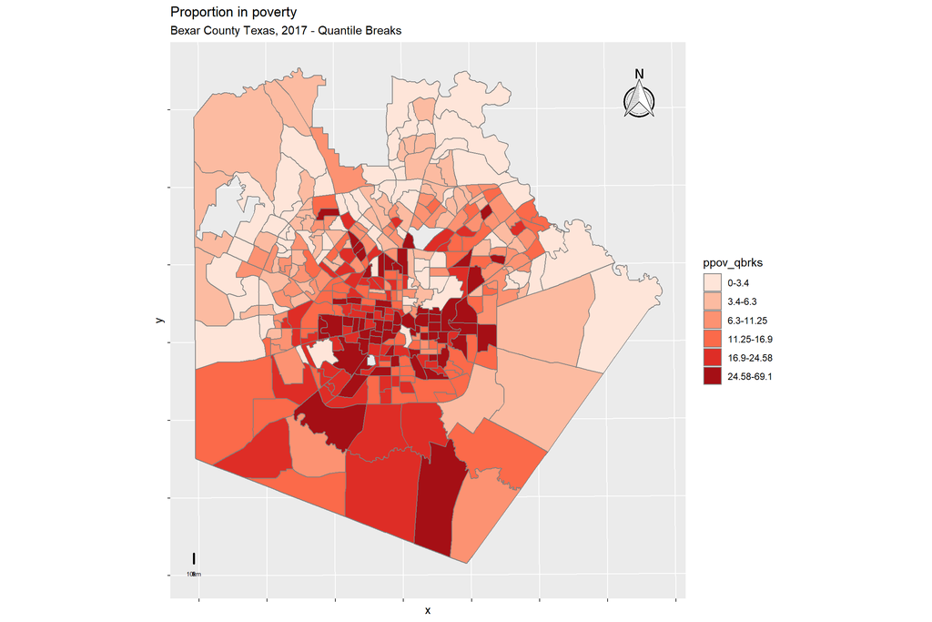

```r
library(patchwork)
library(ggsn)
library(XploreR)
source("https://raw.githubusercontent.com/coreysparks/Rcode/master/mutate_map_funs.R")

ppov_map<-sa_acs2 %>%
  mutate_map_brks(ppov, n=6, style="quantile")%>%
           mutate_map_brks(ppov, n=6, style="jenks")



p1<-ggplot(ppov_map, aes(fill = ppov_qbrks)) +
  geom_sf(color="grey50") +
  ggtitle("Proportion in poverty",
          subtitle = "Bexar County Texas, 2017 - Quantile Breaks")+
    scale_fill_brewer(palette = "Reds") +
  scale_color_brewer(palette = "Reds")+
  theme(axis.text.x = element_blank(),
        axis.text.y = element_blank())+
  north(ppov_map)+
  scalebar(ppov_map, location="bottomleft",
           dist=5, transform = T,
           dist_unit = "km",
           model="WGS84",
           st.size =2 )
p1
```

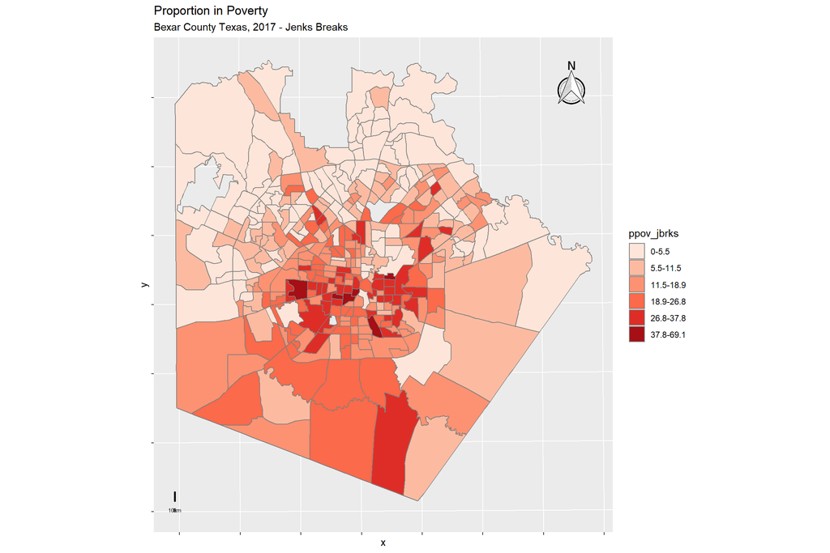

```r
p2<-ggplot(ppov_map, aes(fill = ppov_jbrks)) +
  geom_sf(color="grey50") +
  ggtitle("Proportion in Poverty",
          subtitle = "Bexar County Texas, 2017 - Jenks Breaks")+
  scale_fill_brewer(palette = "Reds") +
  scale_color_brewer(palette = "Reds")+
    theme(axis.text.x = element_blank(),
          axis.text.y = element_blank())+
  north(ppov_map)+
  scalebar(ppov_map,
           location="bottomleft",
           dist=5,
           transform = T,
           dist_unit = "km",
           model="WGS84",
           st.size =2)
p2
```

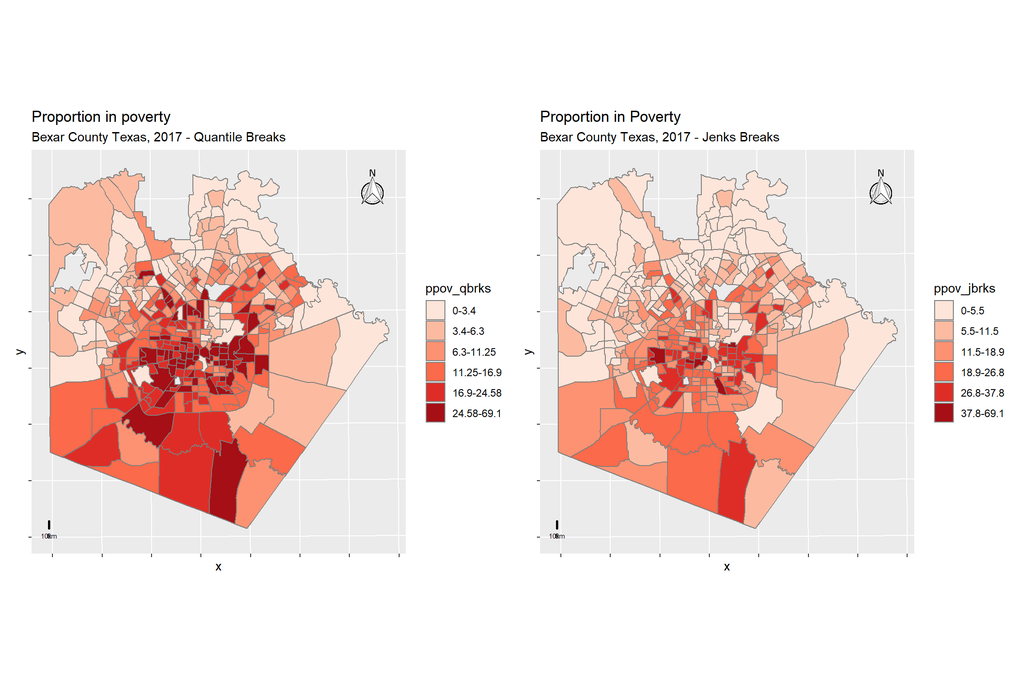

```r
p1+ p2
```

You can save the image from above to your computer by using `ggsave()`

```r
ggsave(filename="../images/lab1map1.png",
       dpi = "print")
```

### Slightly easier way using `tmap`

The `tmap` package is an attractive alternative to using `ggplot()` when making maps, and makes basic cartographic principles easier.

*Note* `style="fisher"` is equivalent to `style="jenks"` and scales better to larger data.

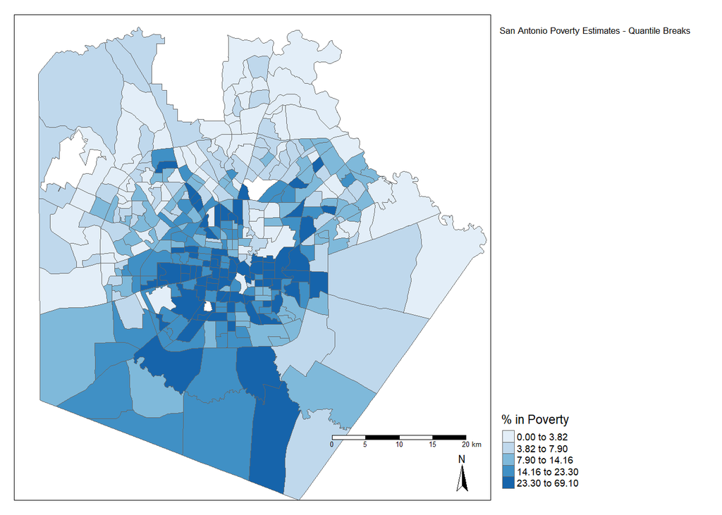

```r
library(tmap)
library(tmaptools)

tm_shape(sa_acs2)+
  tm_polygons("ppov",
              title="% in Poverty",
              palette="Blues",
              style="quantile", n=5 )+
  tm_format("World",
            title="San Antonio Poverty Estimates - Quantile Breaks",
            legend.outside=T)+
  tm_scale_bar()+
  tm_compass()
```

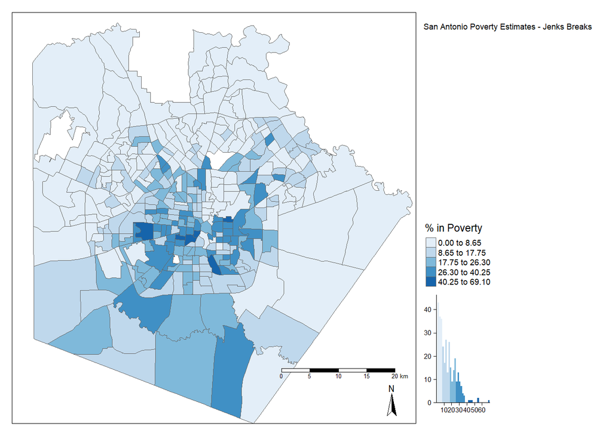

```r
tm_shape(sa_acs2)+
  tm_polygons("ppov",
              title="% in Poverty",
              palette="Blues",
              style="fisher",
              n=5,
              legend.hist=T )+
  tm_format("World",
            title="San Antonio Poverty Estimates - Jenks Breaks",
            legend.outside=T)+
  tm_scale_bar()+
  tm_compass()
```

## Interactive map with mapview

```r
library(mapview)
library(RColorBrewer)
ppov_map$ppov_jbrks<-relevel(ppov_map$ppov_jbrks,ref = "0-5.5" )

pal <- colorRampPalette(brewer.pal(7, "Blues")) #set colors

mapview(ppov_map,
        zcol="ppov_jbrks",
        legend=T,
        map.types="OpenStreetMap",
        layer.name="% in Poverty")
```

[interactive chart not shown]